# LBB8_TS

Ambiya Sang Aji

June 14, 2019

```r
library(forecast)
library(MLmetrics)
library(quantmod)
```

```r
library(MASS)
library(TTR)
library(ggplot2)
library(tseries)
```

# Time Series

Dalam laporan kali ini, penulis akan melakukan forecasting saham google dengan menggunakan library quantmod. forecasting kan dilakukan dengan membandingkan 3 metode, yaitu simple moving average, holt winter dan ARIMA. pertama tama akan dilakukan pengambilan data stock dengan menggunakan library quantmod.

# Analyze and Preprocess Data

```r
#get data and check data
getSymbols('GOOGL')
```

[output not shown]

```
## [1] "GOOGL"
```

```r
head(GOOGL)
```

```
##            GOOGL.Open GOOGL.High GOOGL.Low GOOGL.Close GOOGL.Volume
## 2007-01-03   233.2332   238.5686  230.7858    234.0290     15397500
## 2007-01-04   234.7347   242.2172  234.4094    241.8719     15759400
## 2007-01-05   241.4915   243.9940  239.2943    243.8388     13730400
## 2007-01-08   244.0891   245.1802  241.3413    242.0320      9499200
## 2007-01-09   242.9680   244.3694  240.8408    242.9930     10752000
## 2007-01-10   242.4575   247.0220  241.2613    244.9750     11925000
##            GOOGL.Adjusted
## 2007-01-03       234.0290
## 2007-01-04       241.8719
## 2007-01-05       243.8388
## 2007-01-08       242.0320
## 2007-01-09       242.9930
## 2007-01-10       244.9750
```

```r
tail(GOOGL)
```

```
##            GOOGL.Open GOOGL.High GOOGL.Low GOOGL.Close GOOGL.Volume
## 2019-06-07    1054.28    1073.43   1051.15     1068.37      2191400
## 2019-06-10    1077.00    1094.84   1075.28     1082.76      1425500
## 2019-06-11    1096.99    1104.01   1079.57     1081.04      1675400
## 2019-06-12    1079.95    1082.52   1069.60     1079.10      1183500
## 2019-06-13    1084.71    1096.59   1082.57     1091.01      1040700
## 2019-06-14    1089.74    1094.76   1081.48     1086.30      1229100
##            GOOGL.Adjusted
## 2019-06-07        1068.37
## 2019-06-10        1082.76
## 2019-06-11        1081.04
## 2019-06-12        1079.10
## 2019-06-13        1091.01
## 2019-06-14        1086.30
```

```r
sum(is.na(GOOGL$GOOGL.Adjusted))
```

```
## [1] 0
```

setelah dilakukan pengecekan oleh penulis, data stock didapatkan dari tahun 2007, dan data hanya ada untuk work day saja (senin-jumat). disini penulis akan melakukan forecasting terhadap data adjusted closing price. data juga terlihat tidak memiliki missing value

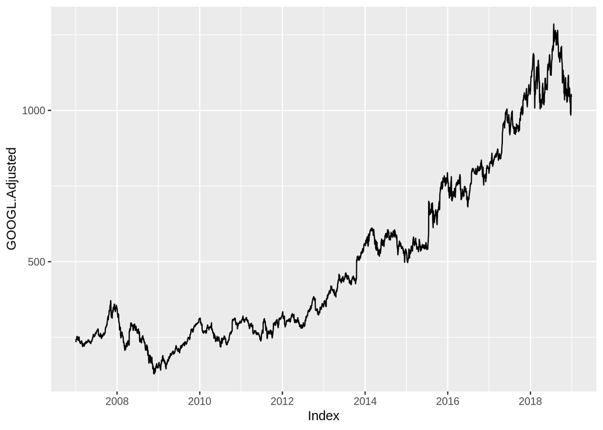

```r
#subset and plot data
adj_ggl <- GOOGL[,6]
adj_ggl <- window(adj_ggl, start='2007-01-01', end='2018-12-31')
autoplot(adj_ggl)
```

Terlihat dari plot bahwa data memiliki trend naik, namun data terlihat tidak memiliki seasonality. akan dilakukan pengecekan decomose data

```r
#check mean dari jumlah row setiap tahun
mean(nrow(window(adj_ggl, start='2007-01-01', end='2007-12-31')),
nrow(window(adj_ggl, start='2008-01-01', end='2008-12-31')),
nrow(window(adj_ggl, start='2009-01-01', end='2009-12-31')),
nrow(window(adj_ggl, start='2010-01-01', end='2010-12-31')),
nrow(window(adj_ggl, start='2011-01-01', end='2011-12-31')),
nrow(window(adj_ggl, start='2012-01-01', end='2012-12-31')),
nrow(window(adj_ggl, start='2013-01-01', end='2013-12-31')),
nrow(window(adj_ggl, start='2014-01-01', end='2014-12-31')),
nrow(window(adj_ggl, start='2015-01-01', end='2015-12-31')),
nrow(window(adj_ggl, start='2016-01-01', end='2016-12-31')),
nrow(window(adj_ggl, start='2017-01-01', end='2017-12-31')),
nrow(window(adj_ggl, start='2018-01-01', end='2018-12-31')))
```

```
## [1] 251
```

Average data 1 tahun adalah 251, akan digunakan angka 251 untuk frequency

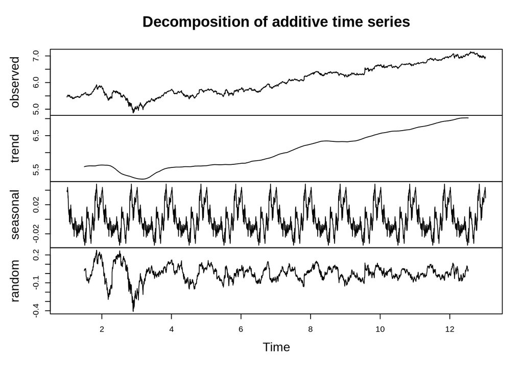

```r
adj_ggl1 <- ts(log(adj_ggl),frequency = 251)
plot(decompose(adj_ggl1))
```

Akan dlakukan pengecekan untuk mengecek apakah data memiliki seasonality atau tidak

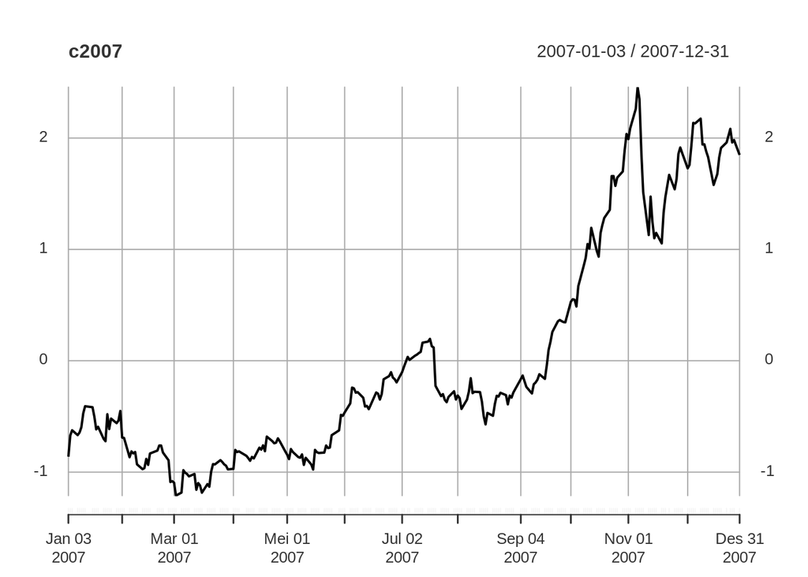

```r
#check plot dari 3 tahun pertama
c2007 <- scale(window(adj_ggl, start='2007-01-01', end='2007-12-31'))
c2008 <- scale(window(adj_ggl, start='2008-01-01', end='2008-12-31'))
c2009 <- scale(window(adj_ggl, start='2009-01-01', end='2009-12-31'))
plot(c2007)
```

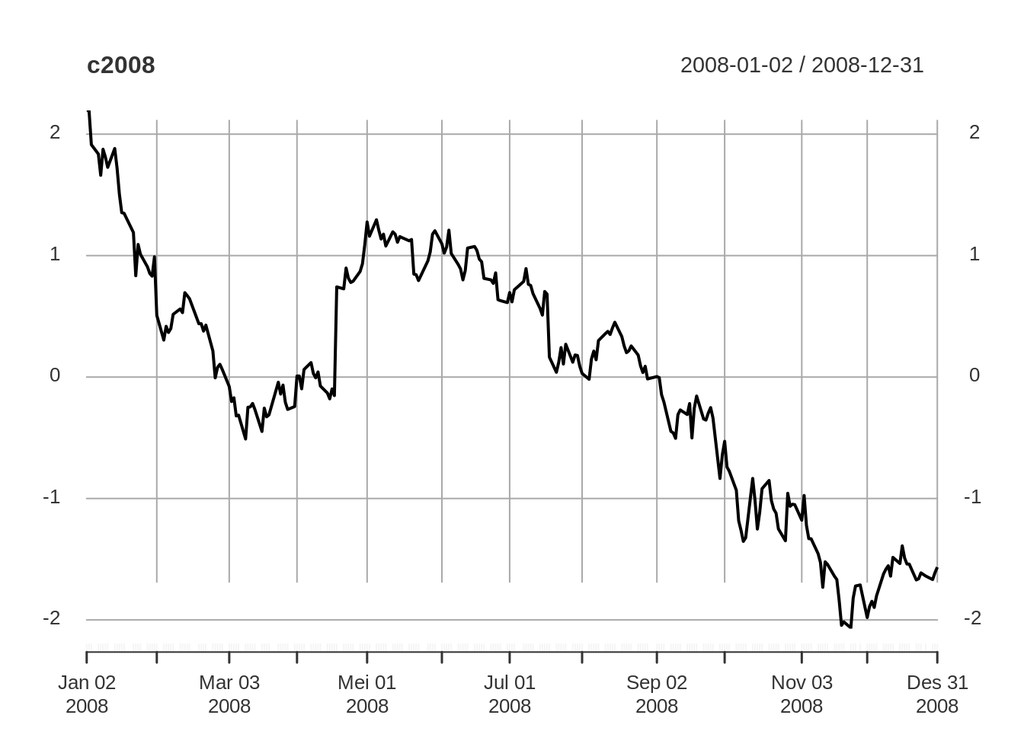

```r
plot(c2008)
```

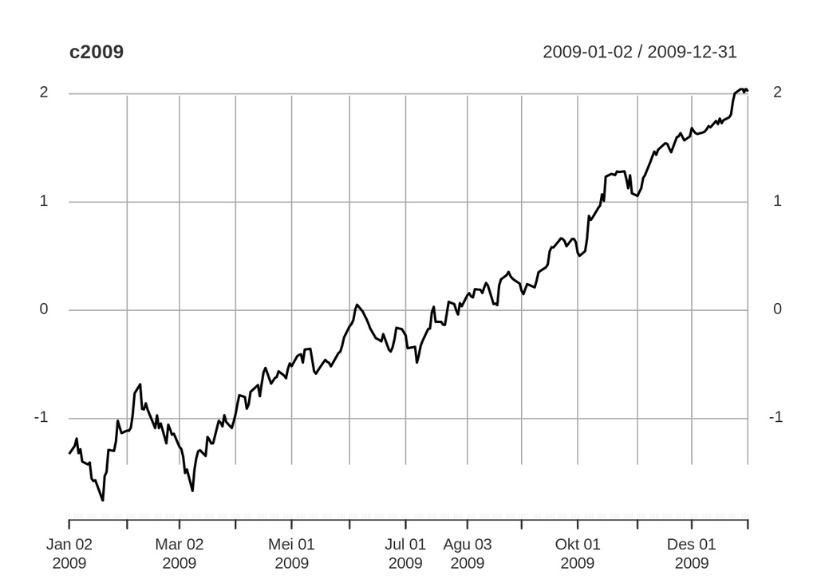

```r
plot(c2009)
```

Data secara tahunan tidak mirip menandakan tidak adanya seasonality

# Modelling Using SMA

Data adj_ggl akan digunakan sebagai data train, dan data tahun 2019 akan digunakan sebagai data testing

```r
#set test data
test <- window(GOOGL$GOOGL.Adjusted, start='2019-01-01', end='2019-06-14')
```

```r
#check best n for SMA
k <- 1
m <- matrix(0, ncol = 3, nrow = 251)
for (i in seq(from=3, to=251, by=1)){
  SMA <- SMA(adj_ggl, n = i)
  SMAFCR <- matrix(0, ncol = 1, nrow = 114+i)
  SMAFCR[1:i,] <- tail(adj_ggl$GOOGL.Adjusted,i)
  z <- 1
    for (j in seq(from=i+1, to=114+i, by=1)){
      SMAFCR[j,] <- mean(SMAFCR[z:i,])
      z <- z+1
      }
  m[k,1] <- i
  m[k,2] <- RMSE(test[,1],SMAFCR[-(1:i),1])
  m[k,3] <- MAPE(test[,1],SMAFCR[-(1:i),1])
  k <- k+1
}
m <- m[order(m[,2], decreasing = FALSE),]
row_sub <- apply(m, 1, function(row) all(row !=0 ))
m <- m[row_sub,]
m[1,]
```

```
## [1] 201.00000000  52.99417864   0.03817957
```

Model terbaik dihasilkan dengan nilai n = 201, dengan nilai RMSE 53, dan nilai MAPE sekitar 0.038

Akan dilakukan plotting untuk melihat model SMA

```r
#SMA using n = 201
SMAFCR <- matrix(0, ncol = 1, nrow = 114+201)
SMAFCR[1:201,] <- tail(adj_ggl$GOOGL.Adjusted,201)
  z <- 1
    for (j in seq(from=202, to=114+201, by=1)){
      SMAFCR[j,] <- mean(SMAFCR[z:j-1,])
      z <- z+1
    }
SMAFCR <- SMAFCR[-(1:201),]
SMAFCR1 <- test
SMAFCR1$GOOGL.Adjusted <- SMAFCR
SMA <- SMA(adj_ggl, n = 201)
```

```r
#format data for plotting purpose
adj_ggl7 <- data.frame(Y=as.matrix(adj_ggl), date=time(adj_ggl))
test1 <- data.frame(Y=as.matrix(test), date=time(test))
SMA1 <- data.frame(Y=as.matrix(SMA), date=time(SMA))
SMA1 <- SMA1[-(1:201),]
SMAFCR2 <- data.frame(Y=as.matrix(SMAFCR1), date=time(SMAFCR1))
```

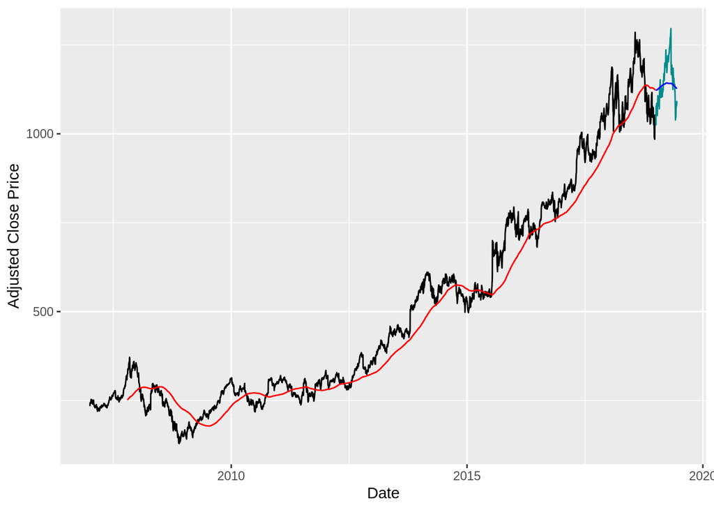

```r
#Plot SMA
ggplot()+
 geom_line(data = adj_ggl7, aes(x = adj_ggl7$date, y = adj_ggl7$GOOGL.Adjusted))+
 geom_line(data = test1, aes(x=test1$date, y=test1$GOOGL.Adjusted), color="darkcyan")+
 geom_line(data=SMA1, aes(x=SMA1$date, y=SMA1$SMA), color="red")+
 geom_line(data = SMAFCR2, aes(x=SMAFCR2$date, y=SMAFCR2$GOOGL.Adjusted), color="blue")+
 xlab("Date")+
 ylab("Adjusted Close Price")
```

Nilai RMSE dan MAPE nya adalah :

```r
RMSE(test1$GOOGL.Adjusted,SMAFCR2$GOOGL.Adjusted)
```

```
## [1] 55.43366
```

```r
MAPE(test1$GOOGL.Adjusted,SMAFCR2$GOOGL.Adjusted)
```

```
## [1] 0.03996707
```

Model SMA cukup baik dalam melakukan forecasting terhadap data stock. dengan nilai RMSE 55 dan MAPE 0.04. selanjutnya akan dilakukan modelling menggunakan metode double exponential smooting (Holt)

# Modelling using Holt

Akan dilakukan modelling beberapa kali menggunakan Holt dengan fungsi ets(), dan akan dilakukan plotting lebih lanjut untuk model dengan nilai terbaik

## Holt1 - ANN

```r
#transform to log for scaling purpose
adj_ggllg <- log(adj_ggl)
```

```r
#Modelling
HLT <- ets(y = adj_ggllg, model = "ANN")
summary(HLT)
```

```
## ETS(A,N,N)
##
## Call:
##  ets(y = adj_ggllg, model = "ANN")
##
##   Smoothing parameters:
##     alpha = 0.9874
##
##   Initial states:
##     l = 5.4558
##
##   sigma:  0.018
##
##       AIC      AICc       BIC
## -50.14448 -50.13652 -32.10545
##
## Training set error measures:
##                        ME      RMSE        MAE         MPE      MAPE
## Training set 0.0005016516 0.0180285 0.01198145 0.007622254 0.2034679
##                  MASE          ACF1
## Training set 1.000001 -0.0005647851
```

Nilai alpha yang ditemukan adalah 0.98, dengan nilai error RMSE sebesar 0.0180285

```r
adj_ggllg1 <- data.frame(Y=as.matrix(adj_ggllg), date=time(adj_ggllg))
HLT1 <- adj_ggllg1
HLT1$GOOGL.Adjusted <- HLT$fitted
```

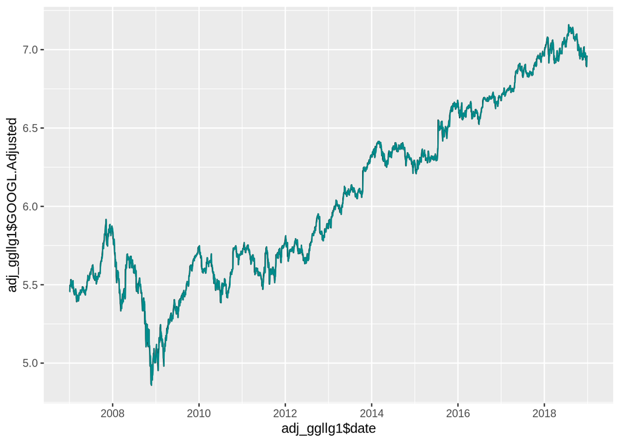

```r
ggplot()+
 geom_line(data = adj_ggllg1, aes(x = adj_ggllg1$date, y = adj_ggllg1$GOOGL.Adjusted),color = "black")+
 geom_line(data = HLT1, aes(x=HLT1$date, y=HLT1$GOOGL.Adjusted), color="darkcyan")
```

Akan dilakukan forecast terhadap data :

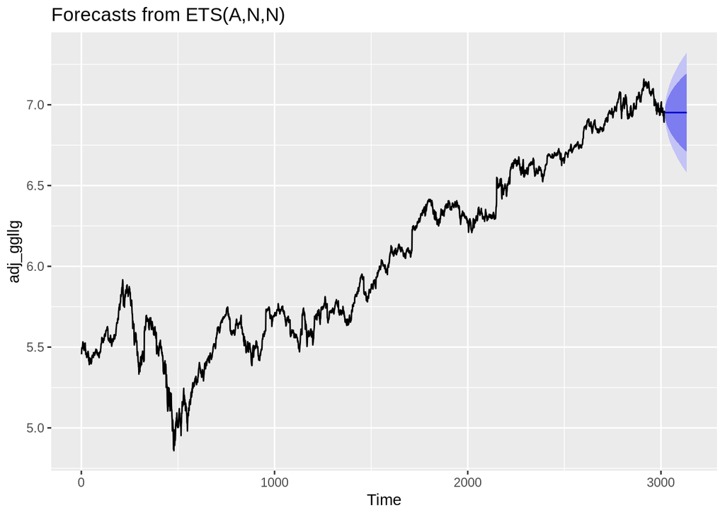

```r
HLTFCT <- forecast(HLT, h = 114)
autoplot(HLTFCT)
```

Dilakukan pengecekan terhadap nilai errornya :

```r
RMSE(test1$GOOGL.Adjusted,exp(HLTFCT$mean))
```

```
## [1] 118.6718
```

```r
MAPE(test1$GOOGL.Adjusted,exp(HLTFCT$mean))
```

```
## [1] 0.09869405
```

Nilai RMSE yang dihasilkan adalah 118, dengan tingkat error sekitar 10%

## Holt 2 - AAN

Akan dilakukan modelling dengan holt, dengan model AAN

```r
HLT2 <- ets(y = adj_ggllg, model = "AAN")
summary(HLT2)
```

```
## ETS(A,A,N)
##
## Call:
##  ets(y = adj_ggllg, model = "AAN")
##
##   Smoothing parameters:
##     alpha = 0.9862
##     beta  = 1e-04
##
##   Initial states:
##     l = 5.4786
##     b = 5e-04
##
##   sigma:  0.018
##
##       AIC      AICc       BIC
## -46.52701 -46.50710 -16.46195
##
## Training set error measures:
##                        ME       RMSE        MAE           MPE      MAPE
## Training set 2.645876e-05 0.01802736 0.01198245 -0.0002693317 0.2035169
##                  MASE          ACF1
## Training set 1.000084 -0.0001535328
```

nilai beta alpha yang ditemukan adalah 0.98 dengan nilai beta yang mendekati 0, dengan nilai RMSE lebih kecil sedikit dari model sebelumnya, yaitu 0.01802736

```r
HLT3 <- adj_ggllg1
HLT3$GOOGL.Adjusted <- HLT2$fitted
```

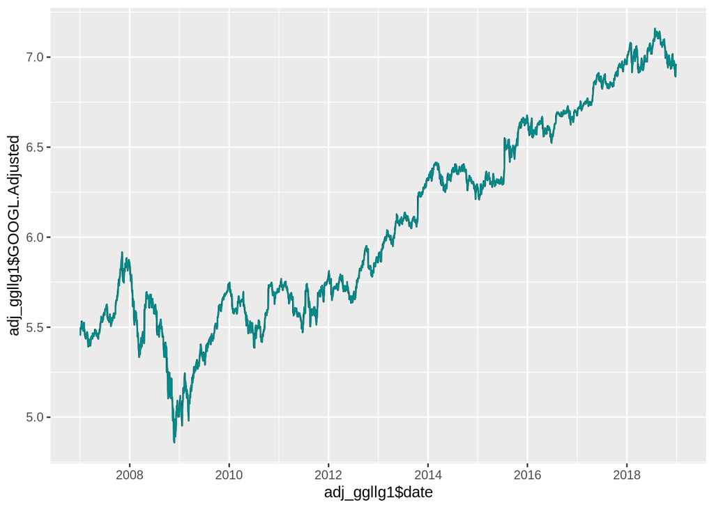

```r
ggplot()+
 geom_line(data = adj_ggllg1, aes(x = adj_ggllg1$date, y = adj_ggllg1$GOOGL.Adjusted),color = "black")+
 geom_line(data = HLT3, aes(x=HLT3$date, y=HLT3$GOOGL.Adjusted), color="darkcyan")
```

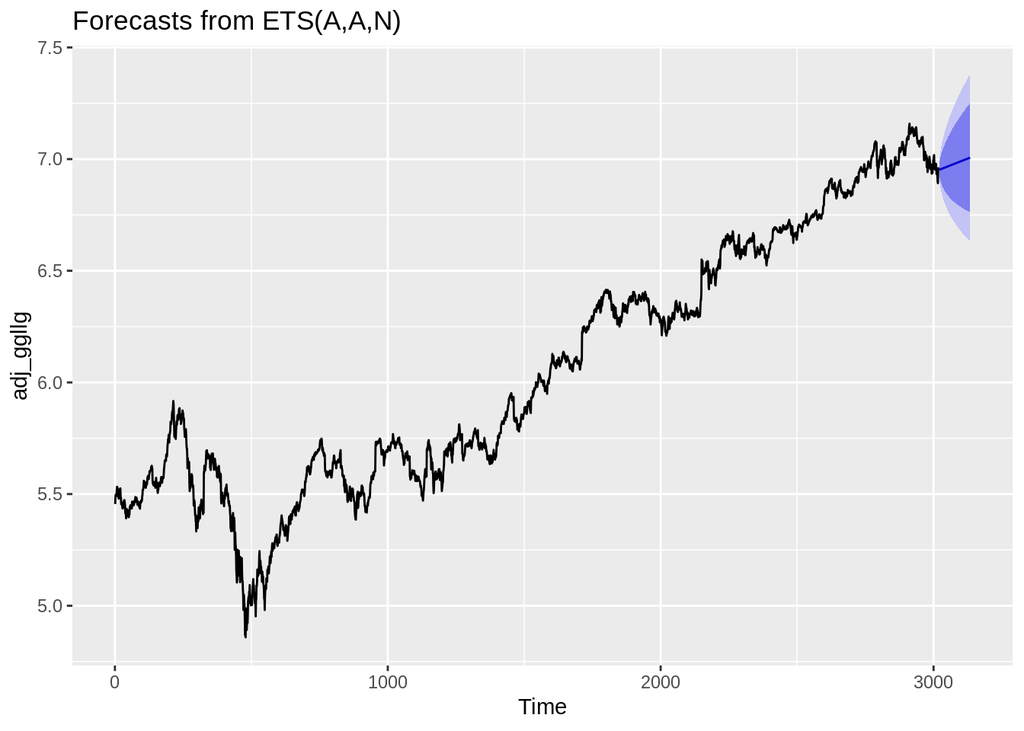

```r
HLTFCT2 <- forecast(HLT2, h = 114)
autoplot(HLTFCT2)
```

Dilakukan pengecekan terhadap niali errornya :

```r
RMSE(test1$GOOGL.Adjusted,exp(HLTFCT2$mean))
```

```
## [1] 92.76022
```

```r
MAPE(test1$GOOGL.Adjusted,exp(HLTFCT2$mean))
```

```
## [1] 0.07396607
```

Didapatkan nilai error lebih baik dibandingkan dengan menggunakan metode ANN

Akan dilakukan plotting lebih lanhut untuk model holt 2, yang akan di plot adalah : data, model, proyeksi dan real data

```r
#format data for plotting purpose
adj_ggl3 <- adj_ggllg1
adj_ggl3$GOOGL.Adjusted <- exp(adj_ggl3$GOOGL.Adjusted)
HLT4 <- adj_ggl3
HLT4$GOOGL.Adjusted <- exp(HLT3$GOOGL.Adjusted)
HLTFCT2Mean <- data.frame(Y=as.matrix(exp(HLTFCT2$mean)), date=time(test1$date))
HLTFCT2Upper <- data.frame(Y=as.matrix(exp(HLTFCT2$upper)), date=time(test1$date))
HLTFCT2Lower <- data.frame(Y=as.matrix(exp(HLTFCT2$lower)), date=time(test1$date))
```

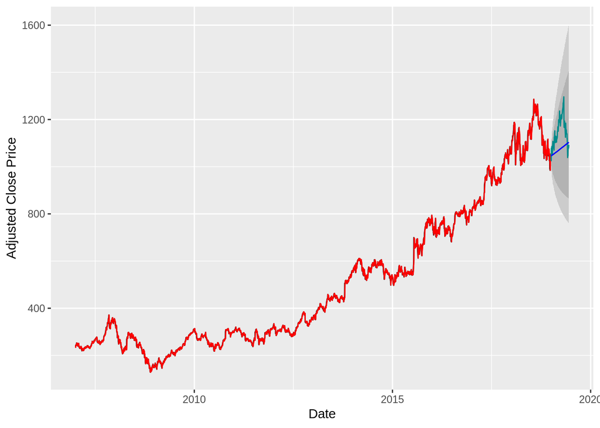

```r
ggplot()+
 geom_line(data = adj_ggl3, aes(x = adj_ggl3$date, y = adj_ggl3$GOOGL.Adjusted))+
 geom_line(data=HLT4, aes(x=HLT4$date, y=HLT4$GOOGL.Adjusted), color="red")+
 geom_ribbon(data =HLTFCT2Upper ,aes(ymin = HLTFCT2Upper$Y.80., ymax = HLTFCT2Upper$Y.95., x=test1$date), fill = "grey80") +
 geom_ribbon(data =HLTFCT2Lower ,aes(ymin = HLTFCT2Lower$Y.80., ymax = HLTFCT2Lower$Y.95., x=test1$date), fill = "grey80") +
 geom_ribbon(aes(ymin = HLTFCT2Lower$Y.80., ymax = HLTFCT2Upper$Y.80., x=test1$date), fill = "grey70") +
 geom_line(data = test1, aes(x=test1$date, y=test1$GOOGL.Adjusted), color="darkcyan")+
 geom_line(data = HLTFCT2Mean, aes(x=test1$date, y=HLTFCT2Mean$Y), color="blue")+
 xlab("Date")+
 ylab("Adjusted Close Price")
```

## Pengecekan asumsi - Holt

Akan dilakukan pengecekan asumsi terhadap model holt

### shapiro test

```r
shapiro.test(HLT2$x - HLT2$fitted)
```

```
##
##  Shapiro-Wilk normality test
##
## data:  HLT2$x - HLT2$fitted
## W = 0.89418, p-value < 2.2e-16
```

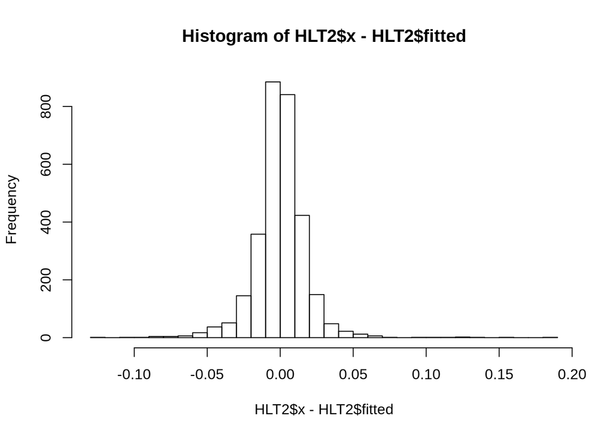

```r
hist(HLT2$x - HLT2$fitted, breaks = 30)
```

Residual yang dihasilkan dibuktikan dengan menggunakan test, tidak menyebar secara normal. Namun oleh karena tujuan dari laporan ini adalah forecasting, dan didapatkan nilai yang sudah cukup bagus, maka hal ini akan diabaikan.

### Ljung Box Test

```r
Box.test(HLT2$x - HLT2$fitted, type = "Ljung-Box")
```

```
##
##  Box-Ljung test
##
## data:  HLT2$x - HLT2$fitted
## X-squared = 7.1259e-05, df = 1, p-value = 0.9933
```

Residual tidak memiliki auto korelasi

Kemudian akan dilakukan modelling dengan menggunakan fungsi HoltWInter()

# Modelling Using Holt Winter Function

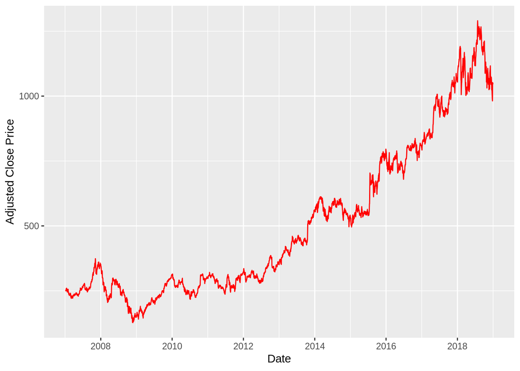

```r
#Model Creation
lgHW <- log(adj_ggl3$GOOGL.Adjusted)
HW <- HoltWinters(lgHW, gamma = F)
#Process data for plotting
HW1 <- data.frame(HW$fitted[,1])
HW1 <- exp(HW1)
#plotting
ggplot()+
 #geom_line(data = adj_ggl3, aes(x = adj_ggl3$date, y = adj_ggl3$GOOGL.Adjusted))+
 geom_line(data=HW1, aes(x=adj_ggl3[-(1:2),2], y=HW1$HW.fitted...1.), color="red")+
 xlab("Date")+
 ylab("Adjusted Close Price")
```

```r
HW$alpha
```

```
##     alpha
## 0.9884711
```

```r
HW$beta
```

```
##       beta
## 0.03317772
```

Model telah dibentuk, akan dilakukan pengecekan error

```r
RMSE(adj_ggl3[-(1:2),1], HW1$HW.fitted...1.)
```

```
## [1] 8.933571
```

```r
MAPE(adj_ggl3[-(1:2),1], HW1$HW.fitted...1.)
```

```
## [1] 0.01225182
```

Nilai RMSE nya adalah 9 dengan error sekitar 1%

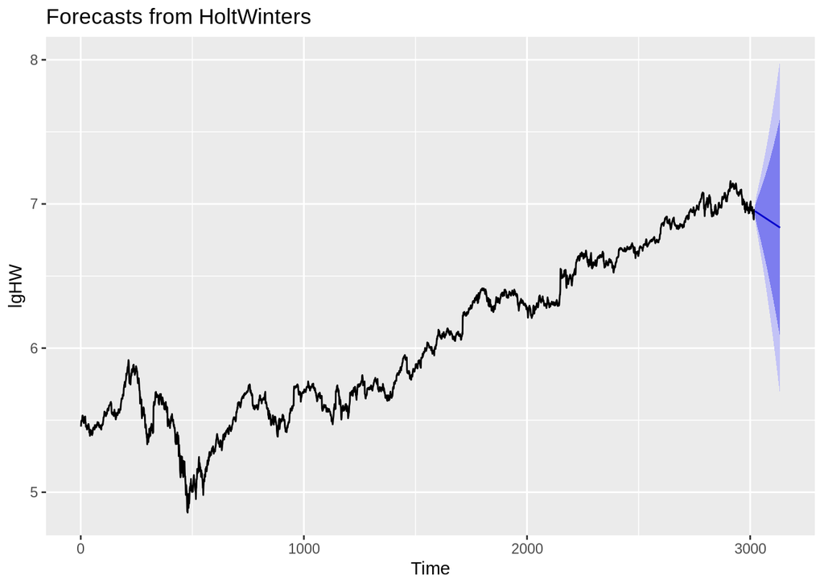

```r
HWFCT <- forecast(HW, h = 114)
autoplot(HWFCT)
```

```r
RMSE(test1$GOOGL.Adjusted,exp(HWFCT$mean))
```

```
## [1] 178.8257
```

```r
MAPE(test1$GOOGL.Adjusted,exp(HWFCT$mean))
```

```
## [1] 0.1660886
```

Nilai yang dihasilkan function Holt Winters Menghasilkan nilai yang lebih buruk dari fungsi ets, dengan nilai RMSE 178 dan tingkat error sekitar 16%. model ini memiliki performansi yang lebih buruk ketmbang menggunakan fungsi ets()

## Pengecekan Asumsi - Holt Winter

### shapiro test

```r
shapiro.test(HW$x - HW$fitted[,1])
```

```
##
##  Shapiro-Wilk normality test
##
## data:  HW$x - HW$fitted[, 1]
## W = 0.89614, p-value < 2.2e-16
```

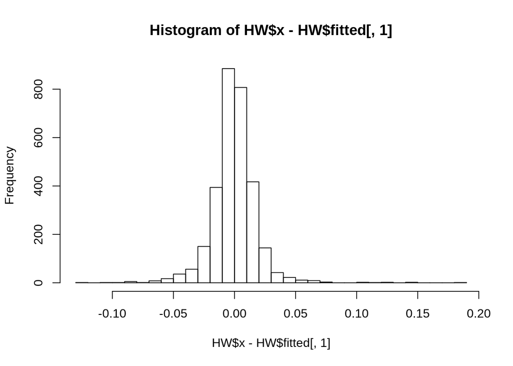

```r
hist(HW$x - HW$fitted[,1], breaks = 30)
```

Residual yang dihasilkan dibuktikan dengan menggunakan test, tidak menyebar secara normal. Namun oleh karena tujuan dari laporan ini adalah forecasting, maka hal ini akan diabaikan.

### Ljung Box Test

```r
Box.test(HW$x - HW$fitted[,1], type = "Ljung-Box")
```

```
##
##  Box-Ljung test
##
## data:  HW$x - HW$fitted[, 1]
## X-squared = 0.00012844, df = 1, p-value = 0.991
```

Residual tidak memiliki auto korelasi

# Modelling Using ARIMA

## Auto-Arima

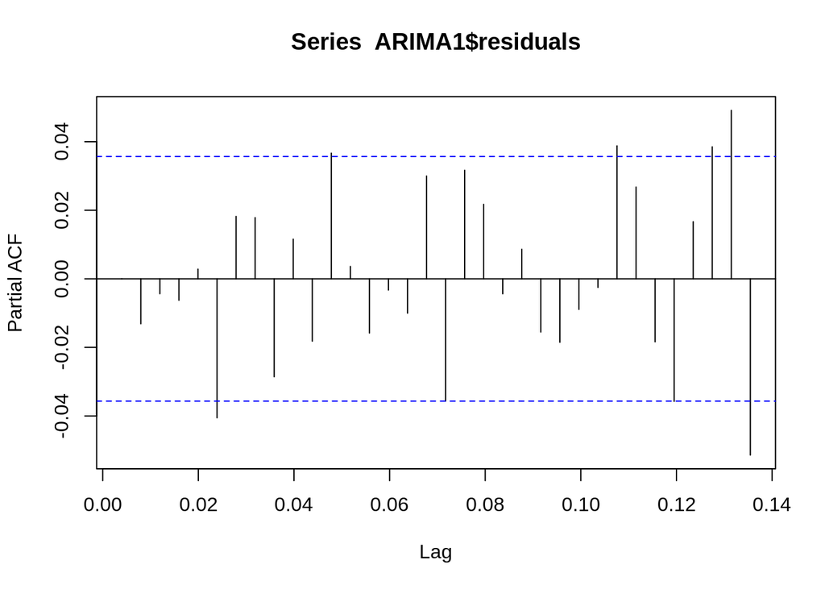

```r
ARIMA1 <- auto.arima(adj_ggl1)
pacf(ARIMA1$residuals)
```

```r
summary(ARIMA1)
```

```
## Series: adj_ggl1
## ARIMA(1,1,0) with drift
##
## Coefficients:
##           ar1  drift
##       -0.0130  5e-04
## s.e.   0.0182  3e-04
##
## sigma^2 estimated as 0.0003251:  log likelihood=7840.59
## AIC=-15675.19   AICc=-15675.18   BIC=-15657.15
##
## Training set error measures:
##                        ME       RMSE        MAE           MPE      MAPE
## Training set 2.850313e-06 0.01802183 0.01197581 -0.0006751005 0.2033975
##                    MASE         ACF1
## Training set 0.05599752 2.029742e-05
```

Hasil yang dihasilkan menggunakan auto-arima adalah menggunakan parameter p=1 dan d=1, menghasilkan nilai RMSE sekitar 0.01

Akan dilakukan forecasting dengan menggunakan model arima tersebut, dan dilakukan pengecekan nilai errornya

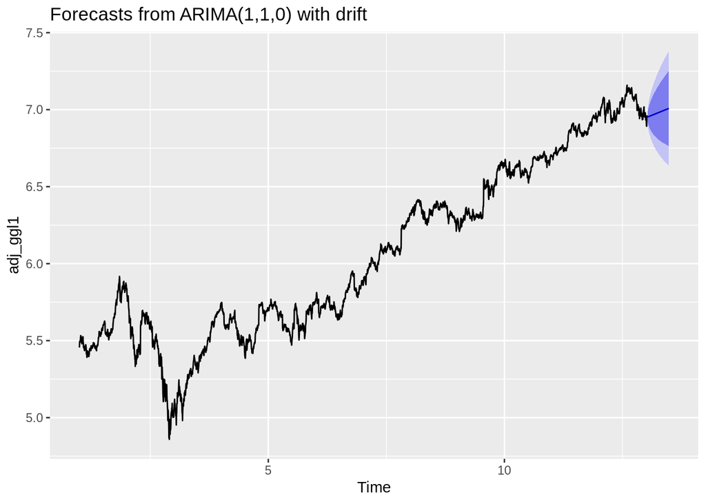

```r
ARIMA1FCT <- forecast(ARIMA1, h = 114)
ARIMA1FCT %>%
autoplot()
```

```r
RMSE(test1$GOOGL.Adjusted,exp(ARIMA1FCT$mean))
```

```
## [1] 92.05389
```

```r
MAPE(test1$GOOGL.Adjusted,exp(ARIMA1FCT$mean))
```

```
## [1] 0.07335181
```

Nilai error yang dihasilkan dari hasil forecasting adalah 92, dengan tingkat error sekitar 7%

## Pengecekan Asumsi - ARIMA

### shapiro test

```r
shapiro.test(ARIMA1$x - ARIMA1$fitted[,1])
```

```
##
##  Shapiro-Wilk normality test
##
## data:  ARIMA1$x - ARIMA1$fitted[, 1]
## W = 0.89398, p-value < 2.2e-16
```

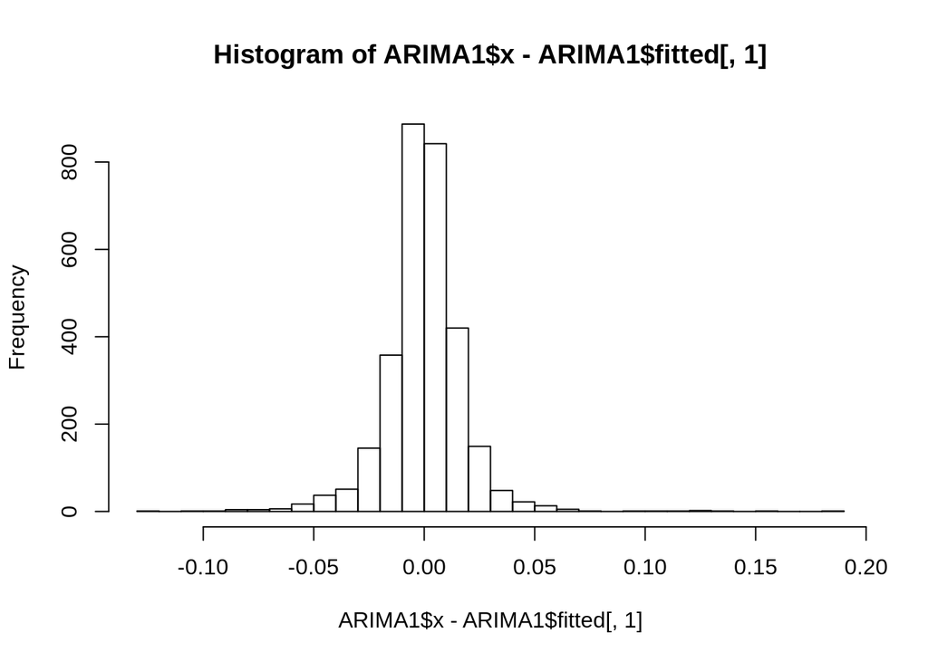

```r
hist(ARIMA1$x - ARIMA1$fitted[,1], breaks = 30)
```

Residual yang dihasilkan dibuktikan dengan menggunakan test, tidak menyebar secara normal. Namun oleh karena tujuan dari laporan ini adalah forecasting, dan didapatkan nilai yang sudah cukup bagus, maka hal ini akan diabaikan.

### Ljung Box Test

```r
Box.test(ARIMA1$x - ARIMA1$fitted[,1], type = "Ljung-Box")
```

```
##
##  Box-Ljung test
##
## data:  ARIMA1$x - ARIMA1$fitted[, 1]
## X-squared = 1.2454e-06, df = 1, p-value = 0.9991
```

Residual tidak memiliki auto korelasi

## Manual ARIMA

Sebelum melakukan modelling, akan dilakukan pengecekan setelah dilakukan differencing apakah data menjadi stasioner

```r
addj_ggl5 <- exp(adj_ggl1)
adjggldiff <- diff(addj_ggl5)
adf.test(adjggldiff)
```

```
##
##  Augmented Dickey-Fuller Test
##
## data:  adjggldiff
## Dickey-Fuller = -15.768, Lag order = 14, p-value = 0.01
## alternative hypothesis: stationary
```

data telah stasioner, seperti yang telah ditunjukkan oleh test, nilai p-value nya < 0.05, menunjukkan data telah stasioner.

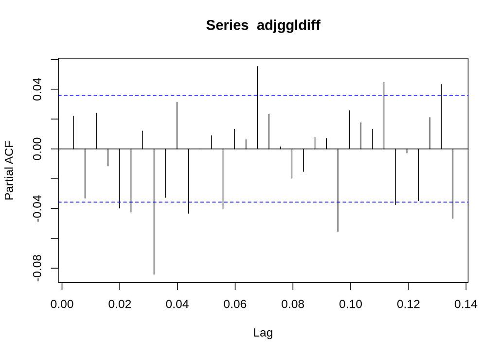

```r
pacf(adjggldiff)
```

Nilai untuk p yang mungkin dilihat dari plot pacf nya adalah : 5,6,8,11,14,16,23,27,28,32,33

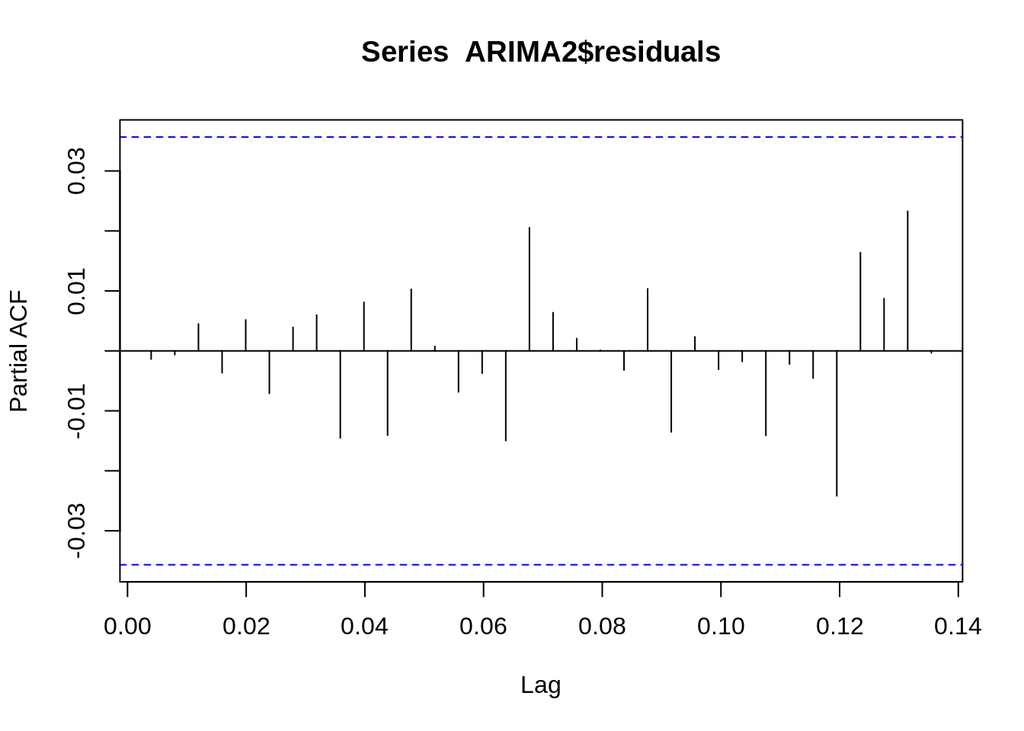

```r
ARIMA2 <- arima(adj_ggl1, order = c(27,1,27))
pacf(ARIMA2$residuals)
```

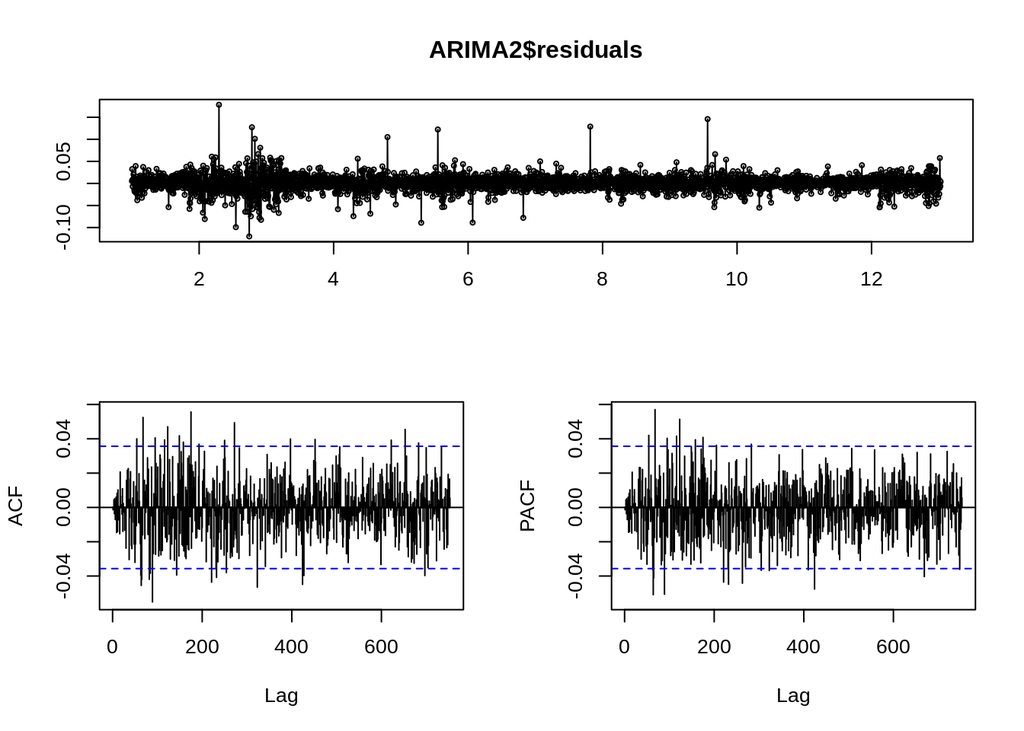

```r
tsdisplay(ARIMA2$residuals)
```

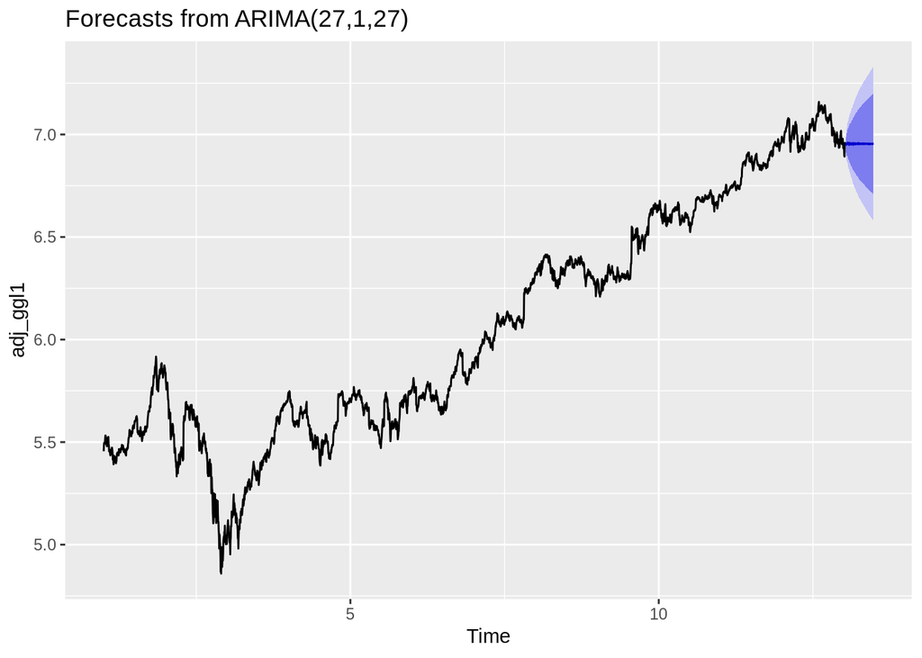

```r
ARIMA2FCT <- forecast(ARIMA2, h = 114)
ARIMA2FCT %>%
autoplot()
```

```r
RMSE(test1$GOOGL.Adjusted,exp(ARIMA2FCT$mean))
```

```
## [1] 116.2767
```

```r
MAPE(test1$GOOGL.Adjusted,exp(ARIMA2FCT$mean))
```

```
## [1] 0.09591736
```

Nilai yang dihasilkan masih lebih baik dengan menggunakan auto arima.

## Pengecekan Asumsi - ARIMA manual

### shapiro test

```r
shapiro.test(ARIMA2$residuals)
```

```
##
##  Shapiro-Wilk normality test
##
## data:  ARIMA2$residuals
## W = 0.90404, p-value < 2.2e-16
```

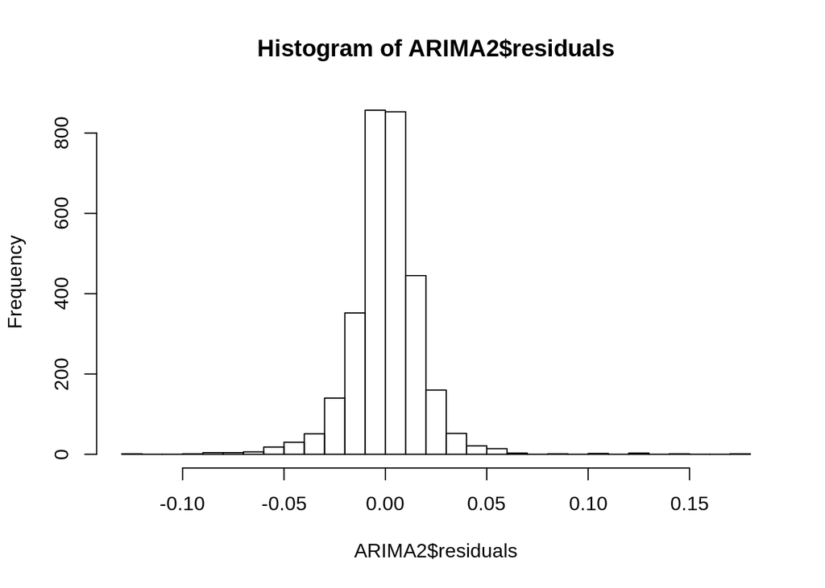

```r
hist(ARIMA2$residuals, breaks = 30)
```

Residual yang dihasilkan dibuktikan dengan menggunakan test, tidak menyebar secara normal. Namun oleh karena tujuan dari laporan ini adalah forecasting, dan didapatkan nilai yang sudah cukup bagus, maka hal ini akan diabaikan.

### Ljung Box Test

```r
Box.test(ARIMA2$residuals, type = "Ljung-Box")
```

```
##
##  Box-Ljung test
##
## data:  ARIMA2$residuals
## X-squared = 0.005611, df = 1, p-value = 0.9403
```

Residual tidak memiliki auto korelasi

# Kesimpulan

Dalam kasus ini, metode Simple Moving Average menghasilkan nilai forecast yang paling baik diantara 3 metode lain nya. disusul dengan metode auto arima dan holt yang menghasilkan nilai kurang lebih mirip.